# COVID_DC

### Load Packages

The following packages are used:

tidyverse: mutate data

janitor: clean names

ggplot2: create visualizations

tigris: graph maps

sf: load kml files

lubridate: manipulate dates

```r
library(tidyverse)
library(janitor)
```

```r
library(ggplot2)
library(lubridate)
library(tigris)
library(sf)
library(here)
```

### Load data

The data is taken from Open DC. The first data set provides all COVID cases in DC by neighborhood. The link to the data set if found at https://opendata.dc.gov/datasets/62f6f28dbfc74ae489fa3dcda9e94744_28/about.

The second data set provides longitude and latitude for DC Neighborhoods. The data is found at https://opendata.dc.gov/datasets/DCGIS::neighborhood-labels/about.

```r
setwd("~/R/DS_241_bikes_2021")
df1 <- read_csv(here("data","DC_COVID-19_Total_Positive_Cases_by_Neighborhood.csv"))%>%
  clean_names()
df1_loc <- read_csv(here("data","Neighborhood_Labels.csv"))%>%
  clean_names()
```

### clean data

Isolates the neighborhood name from a neighborhood code.

```r
df2 <- df1 %>%
  separate(neighborhood,c("key","neighborhood"), ": ")
```

### Join Data

Allows us to get coordinates and Covid cases in the same dataset

```r
df2_loc <- df1_loc %>%
  dplyr::select("x_dir"=x,"y_dir"=y,label_name)%>%
  mutate(neighborhood=toupper(label_name))%>%
  mutate(neighborhood=case_when(
  neighborhood == "16TH STREET HEIGHTS" ~   "16th ST HEIGHTS" ,
  neighborhood == "CONGRESS HEIGHTS" ~ "CONGRESS HEIGHTS/SHIPLEY",     #missing DC medical center, georgetown east, national mall, south columbia heights, stadium armory, U st/pleasant, union station
  neighborhood == "FOGGY BOTTOM" ~ "FOGGY BOTTOM/GWU",
  neighborhood == "FORT LINCOLN" ~ "FORT LINCOLN/GATEWAY",
  neighborhood  == "GEORGE WASHINGTON UNIVERSITY" ~ "GWU",
  neighborhood == "PALISADES" ~ "KENT/PALISADES",
  neighborhood == "NAVY YARD" ~ "NAVAL STATION & AIR FORCE",
  neighborhood == "HILLCREST" ~ "NAYLOR/HILLCREST",
  neighborhood == "SOUTHWEST/WATERFRONT" ~ "SW/WATERFRONT",
  TRUE~neighborhood))
df3<- left_join(df2,df2_loc,by = "neighborhood")%>%
  dplyr::select(date_reported, neighborhood, total_positives,y_dir,x_dir)
df3$datereported<-ymd_hms(df3$date_reported, tz="UTC")
```

### Sample analysis

Provides a visualization by mapping each neighbourhood, and colorizing plot accoding to covid cases

```r
df4<- df3 %>%
  filter(year(date_reported)== 2021,month(date_reported)== 9)%>%
  group_by(neighborhood)%>%
  summarize(CovidCases= sum(total_positives), x_dir, y_dir)
```

[figure not shown]

```r
ggplot(df4, aes(x = x_dir, y= y_dir,color = CovidCases)) +
  geom_point(size=4)+labs(title= "Total cases by neighborhood in DC", subtitle = "September 2021")+ xlab("latitude")+ylab("latitude")
```

applying a border on DC, we get:

```r
us_states <- county_subdivisions("DC","District of Columbia")
```

[output not shown]

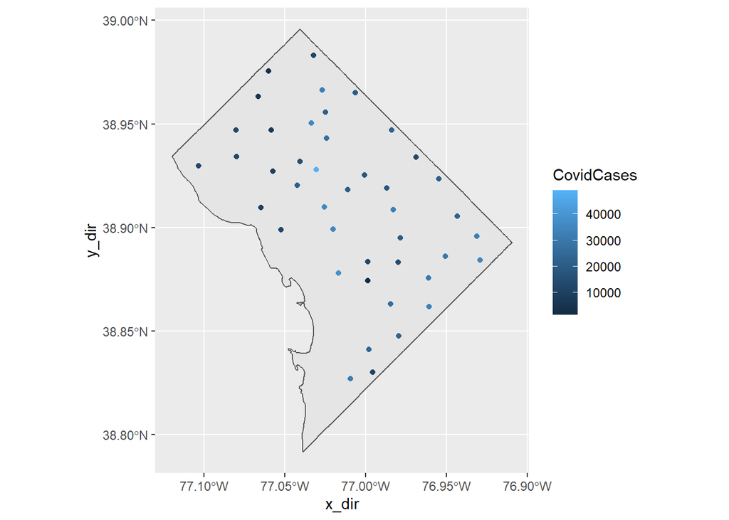

```r
ggplot(us_states)+geom_sf()+geom_point(data= df4,aes(x = x_dir, y= y_dir, color= CovidCases))
```

Using the GIS data for DC neighborhoods found at https://www.google.com/maps/d/u/0/viewer?mid=1z_3yTY-G8hZZ3z5qh3tM9dBh5ps&ll=38.90259760569627%2C-77.01308710000002&z=10, we then plotted the neighborhoods and the points

```r
cgg <- st_read(here("data","Washington_DC_neighborhoods.kml"))
```

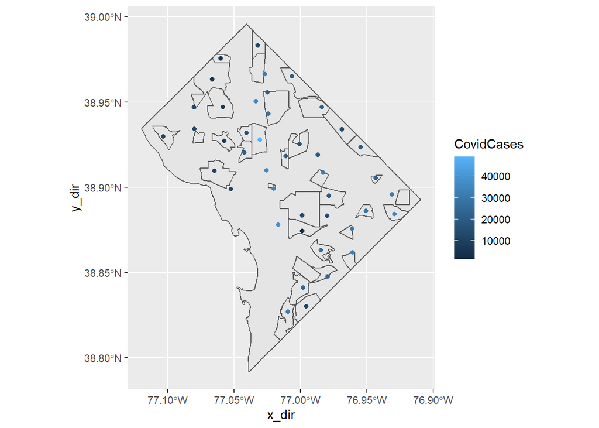

```r
cgg1 <- cgg %>%
  mutate(neighborhood=toupper(Description))
cgg2 <- cgg1%>%
    mutate(neighborhood=case_when(
  neighborhood=="ANACOSTIA" ~ "HISTORIC ANACOSTIA",
  neighborhood=="CONGRESS HEIGHTS" ~ "CONGRESS HEIGHTS/SHIPLEY",
  neighborhood=="FORT LINCOLN" ~ "FORT LINCOLN/GATEWAY",
  neighborhood=="KENT" ~ "KENT/PALISADES",
  neighborhood=="Logan Circle" ~ "LOGAN CIRCLE/SHAW",
  neighborhood=="NAVY YARD" ~ "NAVAL STATION & AIR FORCE",
  neighborhood=="NAYLOR GARDENS" ~ "NAYLOR/HILLCREST",
    TRUE ~ neighborhood
    ))%>%
  filter (neighborhood %in% c(df4$neighborhood))
ggplot(us_states)+geom_sf()+geom_sf(data = cgg2)+geom_point(data= df4,aes(x = x_dir, y= y_dir, color= CovidCases))
```

We then joined the data together to get a plot where insead of points, we colorize the area of the graph.

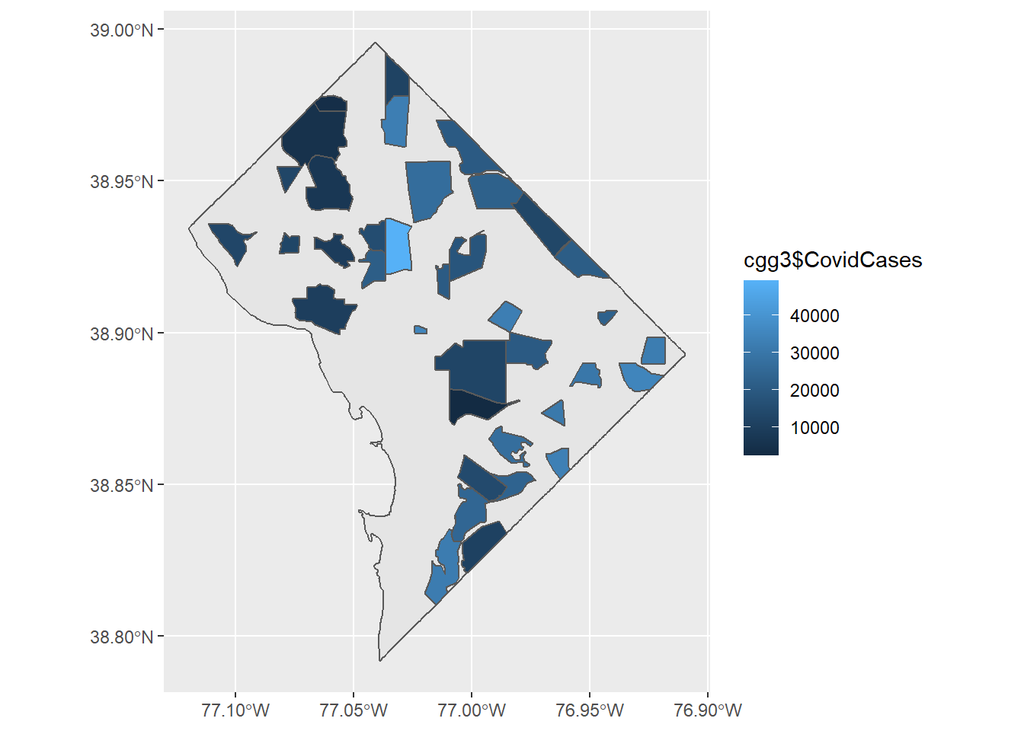

```r
cgg3<- inner_join(df4,cgg2,by = "neighborhood")%>%
  dplyr::select(neighborhood,geometry,CovidCases)
ggplot(data = cgg3$geometry, )+geom_sf(data=us_states$geometry)+geom_sf(aes(fill=cgg3$CovidCases))
```

As you can see currently, not all of DC is filled in. When making the joins, we ended up dropping some of the points as they were not in all of our data sets. Further research and adding locations by hand will be needed to make this data more complete.

Update: a better data set and method of mapping were introduced to the class, will not pursue this further and instead will use class method.

Reflection: This code was my attempt to figure out if our covid data could be graphed. I was unaware of a data set linking covid cases to neighborhoods, so tried to manually find data that would match up. As you can see,I failed to do this but still learned important skills pertaining to mapping and finding data.